# BHao_HW1

```r
train_raw = read.csv("~/Google Drive/CUNY/git/DATA621/HW1/moneyball-training-data.csv")
```

## Data Exploration

Our primary objectives for data exploration are two fold:

1. To get a general sense for our data via summary statistics and visualizations
2. To highlight potential data integrity issues that will need to be addressed in the following data preparation phase

*Note: data exploration, data preparation and model building may be somewhat iterative processes*

- We start by summarizing our data. A couple things immediately jump out:
  - 0 minimum values, especially in the TARGET_WINS column
  - NAs in several columns

```
##      INDEX         TARGET_WINS     TEAM_BATTING_H TEAM_BATTING_2B
##  Min.   :   1.0   Min.   :  0.00   Min.   : 891   Min.   : 69.0
##  1st Qu.: 630.8   1st Qu.: 71.00   1st Qu.:1383   1st Qu.:208.0
##  Median :1270.5   Median : 82.00   Median :1454   Median :238.0
##  Mean   :1268.5   Mean   : 80.79   Mean   :1469   Mean   :241.2
##  3rd Qu.:1915.5   3rd Qu.: 92.00   3rd Qu.:1537   3rd Qu.:273.0
##  Max.   :2535.0   Max.   :146.00   Max.   :2554   Max.   :458.0
##
##  TEAM_BATTING_3B  TEAM_BATTING_HR  TEAM_BATTING_BB TEAM_BATTING_SO
##  Min.   :  0.00   Min.   :  0.00   Min.   :  0.0   Min.   :   0.0
##  1st Qu.: 34.00   1st Qu.: 42.00   1st Qu.:451.0   1st Qu.: 548.0
##  Median : 47.00   Median :102.00   Median :512.0   Median : 750.0
##  Mean   : 55.25   Mean   : 99.61   Mean   :501.6   Mean   : 735.6
##  3rd Qu.: 72.00   3rd Qu.:147.00   3rd Qu.:580.0   3rd Qu.: 930.0
##  Max.   :223.00   Max.   :264.00   Max.   :878.0   Max.   :1399.0
##                                                    NA's   :102
##  TEAM_BASERUN_SB TEAM_BASERUN_CS TEAM_BATTING_HBP TEAM_PITCHING_H
##  Min.   :  0.0   Min.   :  0.0   Min.   :29.00    Min.   : 1137
##  1st Qu.: 66.0   1st Qu.: 38.0   1st Qu.:50.50    1st Qu.: 1419
##  Median :101.0   Median : 49.0   Median :58.00    Median : 1518
##  Mean   :124.8   Mean   : 52.8   Mean   :59.36    Mean   : 1779
##  3rd Qu.:156.0   3rd Qu.: 62.0   3rd Qu.:67.00    3rd Qu.: 1682
##  Max.   :697.0   Max.   :201.0   Max.   :95.00    Max.   :30132
##  NA's   :131     NA's   :772     NA's   :2085
##  TEAM_PITCHING_HR TEAM_PITCHING_BB TEAM_PITCHING_SO  TEAM_FIELDING_E
##  Min.   :  0.0    Min.   :   0.0   Min.   :    0.0   Min.   :  65.0
##  1st Qu.: 50.0    1st Qu.: 476.0   1st Qu.:  615.0   1st Qu.: 127.0
##  Median :107.0    Median : 536.5   Median :  813.5   Median : 159.0
##  Mean   :105.7    Mean   : 553.0   Mean   :  817.7   Mean   : 246.5
##  3rd Qu.:150.0    3rd Qu.: 611.0   3rd Qu.:  968.0   3rd Qu.: 249.2
##  Max.   :343.0    Max.   :3645.0   Max.   :19278.0   Max.   :1898.0
##                                    NA's   :102
##  TEAM_FIELDING_DP
##  Min.   : 52.0
##  1st Qu.:131.0
##  Median :149.0
##  Mean   :146.4
##  3rd Qu.:164.0
##  Max.   :228.0
##  NA's   :286
```

- Next, let’s look at each column’s distribution graphically with some boxplots and outline the highlights below:
  - TARGET_WINS: There are a large number of outliers
  - TEAM_BATTING_H: There are a large number of outliers, especially in the higher values
  - TEAM_BATTING_3B: The lower whisker is close to zero, and there are many outliers in the higher values
  - TEAM_BATTING_BB: The IQR is relatively tight; there are a large number of outliers
  - TEAM_BASERUN_SB: There are a large number of outliers in the higher values
  - TEAM_BASERUN_CS: There are a large number of outliers in the higher values
  - TEAM_PITCHING_H: There are an extremely large number of outliers in the higher values
  - TEAM_PITCHING_BB: There are an extremely large number of outliers in the higher values
  - TEAM_PITCHING_SO: There are an extremely large number of outliers in the higher values
  - TEAM_FIELDING_E: There are an extremely large number of outliers in the higher values

*Note: obviously, not having access to the data providers makes it more difficult to make sense of these potential anomalies; however, knowing the total number of at bats and pitches would be very helpful to this end.*

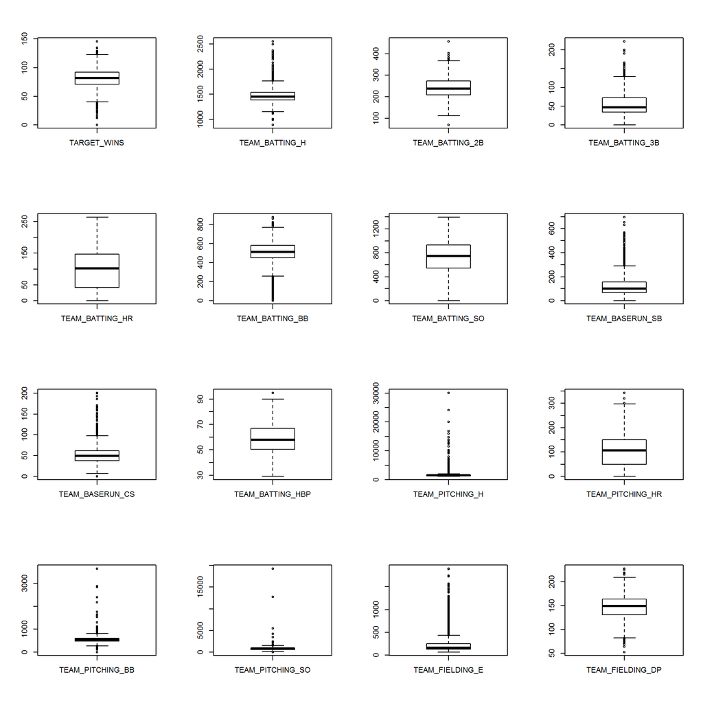

- Next, we examine the correlation between each column and the response variable TARGET_WINS:
  - TEAM_BATTING_H exhibits the highest correlation to the response variable, while TEAM_FIELDING_E exhibits the lowest correlation
  - Surprisingly both TEAM_PITCHING_HR and TEAM_PITCHING_BB exhibit positive correlations to the response variable; we will revisit these anomalies after the data cleansing process to see if they still appear

```
##             rowname   With NAs Ignoring NAs
## 1    TEAM_BATTING_H  0.3887675   0.38876752
## 2   TEAM_BATTING_2B  0.2891036   0.28910365
## 3   TEAM_BATTING_BB  0.2325599   0.23255986
## 4  TEAM_PITCHING_HR  0.1890137   0.18901373
## 5   TEAM_BATTING_HR  0.1761532   0.17615320
## 6   TEAM_BATTING_3B  0.1426084   0.14260841
## 7   TEAM_BASERUN_SB         NA   0.13513892
## 8  TEAM_PITCHING_BB  0.1241745   0.12417454
## 9  TEAM_BATTING_HBP         NA   0.07350424
## 10  TEAM_BASERUN_CS         NA   0.02240407
## 11  TEAM_BATTING_SO         NA  -0.03175071
## 12 TEAM_FIELDING_DP         NA  -0.03485058
## 13 TEAM_PITCHING_SO         NA  -0.07843609
## 14  TEAM_PITCHING_H -0.1099371  -0.10993705
## 15  TEAM_FIELDING_E -0.1764848  -0.17648476
```

- Data exploration summary: The exploration phase revealed that there are a number of potential data issues that will need to be addressed in the data preparation phase:
  - 0 values
  - Missing values
  - Outliers
  - Missing variables - again, it would be very helpful to have the total number of ‘at bats’ and ‘pitches’; however, we can make do without those variables

## Data Preparation

In this phase, we will look at each anomaly and decide how best to address it so that our models can work correclty.

- Since the TEAM_BATTING_H column is inclusive of three other columns, we will start by replacing it with a TEAM_BATTING_1B column

**We’ll replace TEAM_BATTING_H with TEAM_BATTING_1B = TEAM_BATTING_H - TEAM_BATTING_2B - TEAM_BATTING_3B - TEAM_BATTING_HR.**

```r
train_clean = train_raw
train_clean = train_clean %>% mutate(TEAM_BATTING_1B = TEAM_BATTING_H - TEAM_BATTING_2B - TEAM_BATTING_3B - TEAM_BATTING_HR) %>%
  select(-TEAM_BATTING_H)
```

- Let’s next look at the row with 0 wins
  - Most of its columns are either 0 or NA
  - Furthermore, it has a value for TEAM_PITCHING_H (24057) which just does not make sense as that would equate to giving up 148.5 hits on average over 162 games. The median for this field is 1518 which is close to the median value for TEAM_BATTING_H of 1454 - which makes sense as they should be nearly mirror images of each other on average

**It’s safe to assume that this row contains faulty data and should be removed.**

```r
train_clean %>% filter(TARGET_WINS == 0)
```

```
##   INDEX TARGET_WINS TEAM_BATTING_2B TEAM_BATTING_3B TEAM_BATTING_HR
## 1  1347           0             135               0               0
##   TEAM_BATTING_BB TEAM_BATTING_SO TEAM_BASERUN_SB TEAM_BASERUN_CS
## 1               0               0               0               0
##   TEAM_BATTING_HBP TEAM_PITCHING_H TEAM_PITCHING_HR TEAM_PITCHING_BB
## 1               NA           24057                0                0
##   TEAM_PITCHING_SO TEAM_FIELDING_E TEAM_FIELDING_DP TEAM_BATTING_1B
## 1                0            1890               NA             756
```

```r
train_clean = train_clean %>% filter(TARGET_WINS != 0)
```

- Let’s turn our attention to columns with missing data
  - Specifically let’s start with TEAM_BATTING_SO and TEAM_PITCHING_SO, both of which are missing values for the same 102 rows
  - These two columns should be nearly mirror images of each other on average

**We’ll fill in the missing values using their respective median values.**

```r
train_clean = train_clean %>% mutate(
  TEAM_PITCHING_SO = ifelse(is.na(TEAM_PITCHING_SO), median(TEAM_PITCHING_SO, na.rm = TRUE), TEAM_PITCHING_SO),
  TEAM_BATTING_SO = ifelse(is.na(TEAM_BATTING_SO), median(TEAM_BATTING_SO, na.rm = TRUE), TEAM_BATTING_SO))
```

**We’ll use the same approach to fill in the missing values for TEAM_BASERUN_SB, TEAM_BASERUN_CS and TEAM_FIELDING_DP. While we could have used the ratio of average ‘stolen bases’ to ‘caught steals’ multiplied by the ‘stolen bases’ column, we would often then be estimating based on an estimate when the ‘stolen bases’ itself was filled in.**

```r
train_clean = train_clean %>% mutate(
  TEAM_BASERUN_SB = ifelse(is.na(TEAM_BASERUN_SB), median(TEAM_BASERUN_SB, na.rm = TRUE), TEAM_BASERUN_SB),
  TEAM_BASERUN_CS = ifelse(is.na(TEAM_BASERUN_CS), median(TEAM_BASERUN_CS, na.rm = TRUE), TEAM_BASERUN_CS),
  TEAM_FIELDING_DP = ifelse(is.na(TEAM_FIELDING_DP), median(TEAM_FIELDING_DP, na.rm = TRUE), TEAM_FIELDING_DP))
```

- Missing data (cont.)
  - The final column with NAs is the TEAM_BATTING_HBP. Since there are 2084 rows with missing data, it may be best to create a categorical variable to indicate whether TEAM_BATTING_HBP exists or not

**We’ll add a new variable TEAM_BATTING_HBP_YN that is 1 when the TEAM_BATTING_HBP exists and 0 when it does not.**

```r
train_clean = train_clean %>% mutate(TEAM_BATTING_HBP_YN = ifelse(is.na(TEAM_BATTING_HBP), 0, 1))
summary(train_clean)
```

```
##      INDEX         TARGET_WINS     TEAM_BATTING_2B TEAM_BATTING_3B
##  Min.   :   1.0   Min.   : 12.00   Min.   : 69.0   Min.   :  0.00
##  1st Qu.: 630.5   1st Qu.: 71.00   1st Qu.:208.0   1st Qu.: 34.00
##  Median :1270.0   Median : 82.00   Median :238.0   Median : 47.00
##  Mean   :1268.4   Mean   : 80.83   Mean   :241.3   Mean   : 55.27
##  3rd Qu.:1916.0   3rd Qu.: 92.00   3rd Qu.:273.0   3rd Qu.: 72.00
##  Max.   :2535.0   Max.   :146.00   Max.   :458.0   Max.   :223.00
##
##  TEAM_BATTING_HR  TEAM_BATTING_BB TEAM_BATTING_SO  TEAM_BASERUN_SB
##  Min.   :  0.00   Min.   : 12.0   Min.   :   0.0   Min.   :  0.0
##  1st Qu.: 42.00   1st Qu.:451.0   1st Qu.: 557.5   1st Qu.: 67.0
##  Median :102.00   Median :512.0   Median : 750.0   Median :101.0
##  Mean   : 99.66   Mean   :501.8   Mean   : 736.6   Mean   :123.4
##  3rd Qu.:147.00   3rd Qu.:580.0   3rd Qu.: 925.0   3rd Qu.:151.0
##  Max.   :264.00   Max.   :878.0   Max.   :1399.0   Max.   :697.0
##
##  TEAM_BASERUN_CS  TEAM_BATTING_HBP TEAM_PITCHING_H TEAM_PITCHING_HR
##  Min.   :  7.00   Min.   :29.00    Min.   : 1137   Min.   :  0.0
##  1st Qu.: 44.00   1st Qu.:50.50    1st Qu.: 1419   1st Qu.: 50.0
##  Median : 49.00   Median :58.00    Median : 1518   Median :107.0
##  Mean   : 51.54   Mean   :59.36    Mean   : 1769   Mean   :105.7
##  3rd Qu.: 54.50   3rd Qu.:67.00    3rd Qu.: 1682   3rd Qu.:150.0
##  Max.   :201.00   Max.   :95.00    Max.   :30132   Max.   :343.0
##                   NA's   :2084
##  TEAM_PITCHING_BB TEAM_PITCHING_SO  TEAM_FIELDING_E  TEAM_FIELDING_DP
##  Min.   : 119.0   Min.   :    0.0   Min.   :  65.0   Min.   : 52.0
##  1st Qu.: 476.0   1st Qu.:  626.0   1st Qu.: 127.0   1st Qu.:134.0
##  Median : 537.0   Median :  814.0   Median : 159.0   Median :149.0
##  Mean   : 553.3   Mean   :  817.9   Mean   : 245.8   Mean   :146.7
##  3rd Qu.: 611.0   3rd Qu.:  957.0   3rd Qu.: 249.0   3rd Qu.:161.5
##  Max.   :3645.0   Max.   :19278.0   Max.   :1898.0   Max.   :228.0
##
##  TEAM_BATTING_1B TEAM_BATTING_HBP_YN
##  Min.   : 709    Min.   :0.00000
##  1st Qu.: 991    1st Qu.:0.00000
##  Median :1050    Median :0.00000
##  Mean   :1073    Mean   :0.08396
##  3rd Qu.:1129    3rd Qu.:0.00000
##  Max.   :2112    Max.   :1.00000
##
```

- Looking deeper into the TEAM_PITCHING_H column, we see that it contains a large number of outliers
  - Quantifying that shows 213 rows with TEAM_PITCHING_H values greater than 1.5 IQRs above the 3rd quartile

**Instead of removing these rows since they still might contain useful data in the other columns, let’s create a flag to indicate which rows contain outliers in this particular column - this happens to address outliers across all of the pitcher-related columns. Let’s also do the same for other column categories as well.**

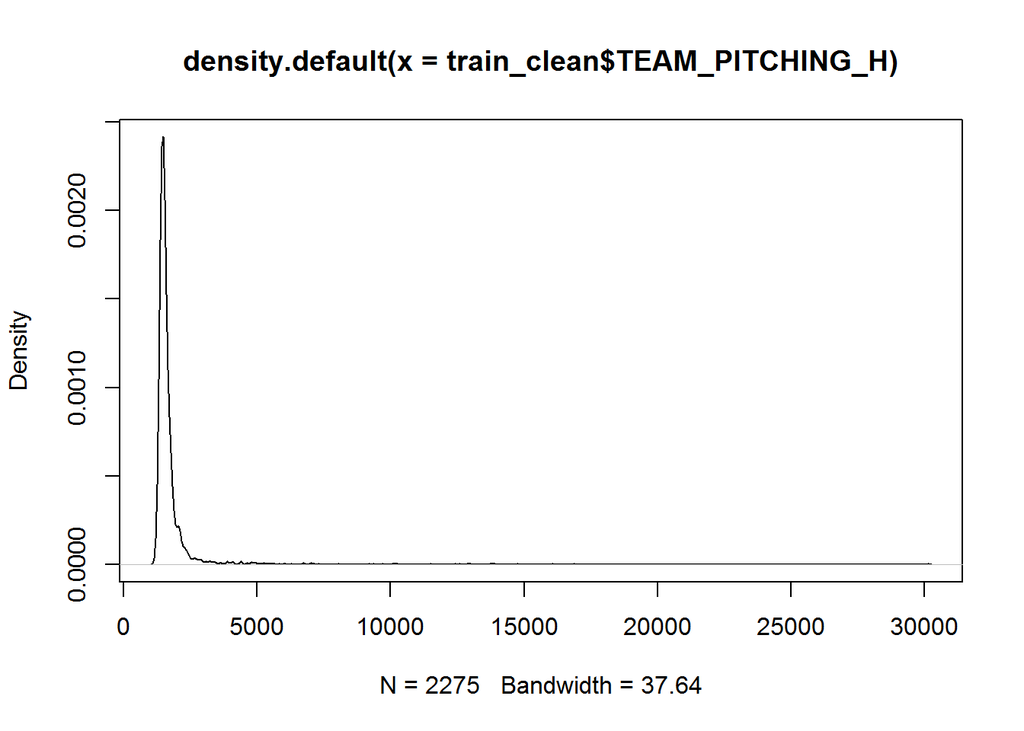

```r
plot(density(train_clean$TEAM_PITCHING_H))
```

```r
train_clean %>% filter(TEAM_PITCHING_H > quantile(TEAM_PITCHING_H, 0.75) + 1.5 * IQR(TEAM_PITCHING_H)) %>%
  summarise(n = n())
```

```
##     n
## 1 213
```

```r
train_clean = train_clean %>%
  mutate('PITCHER_OUTLIER_YN' = ifelse(TEAM_PITCHING_H > quantile(TEAM_PITCHING_H, 0.75) + 1.5 * IQR(TEAM_PITCHING_H) |
                                       TEAM_PITCHING_H < quantile(TEAM_PITCHING_H, 0.25) - 1.5 * IQR(TEAM_PITCHING_H),
                                       1, 0))
train_clean = train_clean %>%
  mutate('BATTING_OUTLIER_YN' = ifelse(TEAM_BATTING_1B > quantile(TEAM_BATTING_1B, 0.75) + 1.5 * IQR(TEAM_BATTING_1B) |
                                       TEAM_BATTING_1B < quantile(TEAM_BATTING_1B, 0.25) - 1.5 * IQR(TEAM_BATTING_1B),
                                       1, 0))
train_clean = train_clean %>%
  mutate('BATTING_OUTLIER_YN' = ifelse(TEAM_BATTING_1B > quantile(TEAM_BATTING_1B, 0.75) + 1.5 * IQR(TEAM_BATTING_1B) |
                                       TEAM_BATTING_1B < quantile(TEAM_BATTING_1B, 0.25) - 1.5 * IQR(TEAM_BATTING_1B),
                                       1, 0))
train_clean = train_clean %>%
  mutate('BASERUN_OUTLIER_YN' = ifelse(TEAM_BASERUN_SB > quantile(TEAM_BASERUN_SB, 0.75) + 1.5 * IQR(TEAM_BASERUN_SB) |
                                       TEAM_BASERUN_SB < quantile(TEAM_BASERUN_SB, 0.25) - 1.5 * IQR(TEAM_BASERUN_SB),
                                       1, 0))
train_clean = train_clean %>%
  mutate('FIELDING_OUTLIER_YN' = ifelse(TEAM_FIELDING_E > quantile(TEAM_FIELDING_E, 0.75) + 1.5 * IQR(TEAM_FIELDING_E) |
                                       TEAM_FIELDING_E < quantile(TEAM_FIELDING_E, 0.25) - 1.5 * IQR(TEAM_FIELDING_E),
                                       1, 0))
```

- Next, we’ll create some new variables based on ratios of the existing variables. Not only will this scale and normalize the variables, it may also create variables that have a better explain the response variable
  - TARGET_WINS_Ratio = TARGET_WINS / 162 (i.e. the percentage of wins)
  - TEAM_H_Ratio = (TEAM_BATTING_1B + TEAM_BATTING_2B + TEAM_BATTING_3B + TEAM_BATTING_HR) / TEAM_PITCHING_H (i.e. the ratio of hits earned to hits allowed)
  - TEAM_BASERUN_Ratio = TEAM_BASERUN_SB / TEAM_BASERUN_CS (i.e. the ratio of successful steals to unsuccessful ones)
  - TEAM_HR_SO_Ratio = TEAM_BATTING_HR / TEAM_BATTING_SO (i.e. the ratio of homeruns to strikeouts)

```r
train_clean = train_clean %>%
  mutate(TARGET_WINS_Ratio = TARGET_WINS / 162,
         TEAM_H_Ratio = (TEAM_BATTING_1B + TEAM_BATTING_2B + TEAM_BATTING_3B + TEAM_BATTING_HR) / TEAM_PITCHING_H,
         TEAM_BASERUN_Ratio = TEAM_BASERUN_SB / TEAM_BASERUN_CS,
         TEAM_HR_SO_Ratio = TEAM_BATTING_HR / ifelse(TEAM_BATTING_SO == 0, median(TEAM_BATTING_SO), TEAM_BATTING_SO))
```

- Let’s now revisit our earlier data explorations. Well, we certainly removed the missing values, but it does not yet look like our new variables will be very promising

```
##      INDEX         TARGET_WINS     TEAM_BATTING_2B TEAM_BATTING_3B
##  Min.   :   1.0   Min.   : 12.00   Min.   : 69.0   Min.   :  0.00
##  1st Qu.: 630.5   1st Qu.: 71.00   1st Qu.:208.0   1st Qu.: 34.00
##  Median :1270.0   Median : 82.00   Median :238.0   Median : 47.00
##  Mean   :1268.4   Mean   : 80.83   Mean   :241.3   Mean   : 55.27
##  3rd Qu.:1916.0   3rd Qu.: 92.00   3rd Qu.:273.0   3rd Qu.: 72.00
##  Max.   :2535.0   Max.   :146.00   Max.   :458.0   Max.   :223.00
##
##  TEAM_BATTING_HR  TEAM_BATTING_BB TEAM_BATTING_SO  TEAM_BASERUN_SB
##  Min.   :  0.00   Min.   : 12.0   Min.   :   0.0   Min.   :  0.0
##  1st Qu.: 42.00   1st Qu.:451.0   1st Qu.: 557.5   1st Qu.: 67.0
##  Median :102.00   Median :512.0   Median : 750.0   Median :101.0
##  Mean   : 99.66   Mean   :501.8   Mean   : 736.6   Mean   :123.4
##  3rd Qu.:147.00   3rd Qu.:580.0   3rd Qu.: 925.0   3rd Qu.:151.0
##  Max.   :264.00   Max.   :878.0   Max.   :1399.0   Max.   :697.0
##
##  TEAM_BASERUN_CS  TEAM_BATTING_HBP TEAM_PITCHING_H TEAM_PITCHING_HR
##  Min.   :  7.00   Min.   :29.00    Min.   : 1137   Min.   :  0.0
##  1st Qu.: 44.00   1st Qu.:50.50    1st Qu.: 1419   1st Qu.: 50.0
##  Median : 49.00   Median :58.00    Median : 1518   Median :107.0
##  Mean   : 51.54   Mean   :59.36    Mean   : 1769   Mean   :105.7
##  3rd Qu.: 54.50   3rd Qu.:67.00    3rd Qu.: 1682   3rd Qu.:150.0
##  Max.   :201.00   Max.   :95.00    Max.   :30132   Max.   :343.0
##                   NA's   :2084
##  TEAM_PITCHING_BB TEAM_PITCHING_SO  TEAM_FIELDING_E  TEAM_FIELDING_DP
##  Min.   : 119.0   Min.   :    0.0   Min.   :  65.0   Min.   : 52.0
##  1st Qu.: 476.0   1st Qu.:  626.0   1st Qu.: 127.0   1st Qu.:134.0
##  Median : 537.0   Median :  814.0   Median : 159.0   Median :149.0
##  Mean   : 553.3   Mean   :  817.9   Mean   : 245.8   Mean   :146.7
##  3rd Qu.: 611.0   3rd Qu.:  957.0   3rd Qu.: 249.0   3rd Qu.:161.5
##  Max.   :3645.0   Max.   :19278.0   Max.   :1898.0   Max.   :228.0
##
##  TEAM_BATTING_1B TEAM_BATTING_HBP_YN PITCHER_OUTLIER_YN BATTING_OUTLIER_YN
##  Min.   : 709    Min.   :0.00000     Min.   :0.00000    Min.   :0.00000
##  1st Qu.: 991    1st Qu.:0.00000     1st Qu.:0.00000    1st Qu.:0.00000
##  Median :1050    Median :0.00000     Median :0.00000    Median :0.00000
##  Mean   :1073    Mean   :0.08396     Mean   :0.09363    Mean   :0.03341
##  3rd Qu.:1129    3rd Qu.:0.00000     3rd Qu.:0.00000    3rd Qu.:0.00000
##  Max.   :2112    Max.   :1.00000     Max.   :1.00000    Max.   :1.00000
##
##  BASERUN_OUTLIER_YN FIELDING_OUTLIER_YN TARGET_WINS_Ratio
##  Min.   :0.00000    Min.   :0.0000      Min.   :0.07407
##  1st Qu.:0.00000    1st Qu.:0.0000      1st Qu.:0.43827
##  Median :0.00000    Median :0.0000      Median :0.50617
##  Mean   :0.05978    Mean   :0.1327      Mean   :0.49893
##  3rd Qu.:0.00000    3rd Qu.:0.0000      3rd Qu.:0.56790
##  Max.   :1.00000    Max.   :1.0000      Max.   :0.90123
##
##   TEAM_H_Ratio     TEAM_BASERUN_Ratio TEAM_HR_SO_Ratio
##  Min.   :0.04938   Min.   : 0.000     Min.   :0.00000
##  1st Qu.:0.93223   1st Qu.: 1.448     1st Qu.:0.08543
##  Median :0.95069   Median : 2.059     Median :0.13463
##  Mean   :0.91475   Mean   : 2.466     Mean   :0.13034
##  3rd Qu.:1.00000   3rd Qu.: 2.806     3rd Qu.:0.17306
##  Max.   :1.01854   Max.   :14.224     Max.   :0.54545
##
```

```
##                rowname  TARGET_WINS
## 1    TARGET_WINS_Ratio  1.000000000
## 2      TEAM_BATTING_2B  0.285964582
## 3     TEAM_HR_SO_Ratio  0.276486605
## 4      TEAM_BATTING_BB  0.225471523
## 5      TEAM_BATTING_1B  0.213402040
## 6     TEAM_PITCHING_HR  0.186326615
## 7      TEAM_BATTING_HR  0.173551988
## 8      TEAM_BATTING_3B  0.139073830
## 9   BATTING_OUTLIER_YN  0.128735272
## 10     TEAM_BASERUN_SB  0.121110012
## 11  TEAM_BASERUN_Ratio  0.119491785
## 12    TEAM_PITCHING_BB  0.117643912
## 13  BASERUN_OUTLIER_YN  0.102242413
## 14        TEAM_H_Ratio  0.083696128
## 15  PITCHER_OUTLIER_YN  0.046631794
## 16     TEAM_BASERUN_CS  0.009835166
## 17 TEAM_BATTING_HBP_YN  0.001939440
## 18    TEAM_FIELDING_DP -0.030050754
## 19     TEAM_BATTING_SO -0.037712096
## 20 FIELDING_OUTLIER_YN -0.053236802
## 21     TEAM_PITCHING_H -0.079145655
## 22    TEAM_PITCHING_SO -0.079711792
## 23     TEAM_FIELDING_E -0.163022098
## 24    TEAM_BATTING_HBP           NA
```

- Let’s also revisit our boxplots filtered to exclude the outliers. Although some outliers remain, the vast majority of them have been filtered out

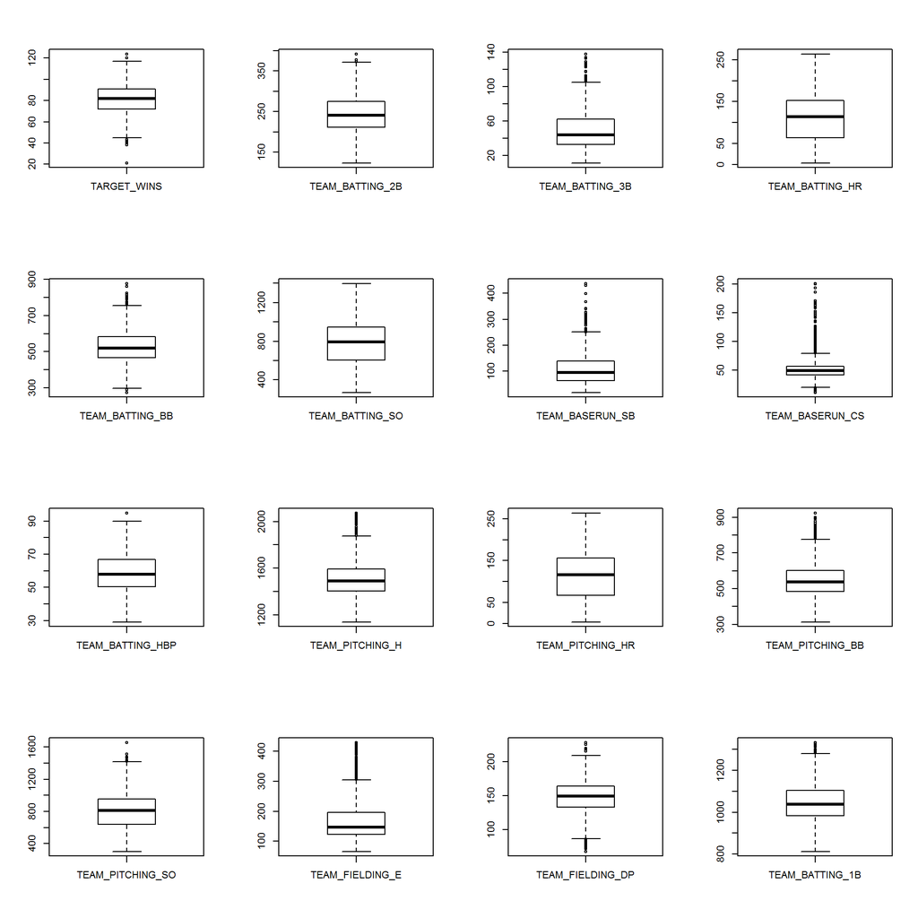

## Build Model

**Backward elimination**

- Let’s start with a backward elimination - we’ll remove -INDEX, -TARGET_WINS_Ratio, -TEAM_BATTING_HBP on the first pass since these are either irrelevant or captured in other columns

```r
train_model1 = train_clean
train_model1 = train_model1 %>% select(-INDEX, -TARGET_WINS_Ratio, -TEAM_BATTING_HBP)
model1 = lm(TARGET_WINS ~ ., data = train_model1)
summary(model1)
```

```
##
## Call:
## lm(formula = TARGET_WINS ~ ., data = train_model1)
##
## Residuals:
##     Min      1Q  Median      3Q     Max
## -51.126  -8.533   0.222   8.115  58.895
##
## Coefficients:
##                       Estimate Std. Error t value Pr(>|t|)
## (Intercept)          6.330e+01  8.493e+00   7.453 1.29e-13 ***
## TEAM_BATTING_2B      2.865e-02  7.671e-03   3.735 0.000193 ***
## TEAM_BATTING_3B      1.280e-01  1.598e-02   8.009 1.84e-15 ***
## TEAM_BATTING_HR      2.359e-01  3.245e-02   7.272 4.87e-13 ***
## TEAM_BATTING_BB      1.989e-02  6.226e-03   3.195 0.001418 **
## TEAM_BATTING_SO     -2.198e-03  3.326e-03  -0.661 0.508734
## TEAM_BASERUN_SB      4.358e-02  2.403e-02   1.814 0.069867 .
## TEAM_BASERUN_CS     -3.547e-02  4.016e-02  -0.883 0.377269
## TEAM_PITCHING_H     -3.362e-04  4.557e-04  -0.738 0.460705
## TEAM_PITCHING_HR    -1.439e-01  3.266e-02  -4.407 1.10e-05 ***
## TEAM_PITCHING_BB    -4.376e-03  4.463e-03  -0.980 0.326960
## TEAM_PITCHING_SO     9.948e-04  9.272e-04   1.073 0.283435
## TEAM_FIELDING_E     -4.989e-02  4.111e-03 -12.135  < 2e-16 ***
## TEAM_FIELDING_DP    -1.271e-01  1.318e-02  -9.638  < 2e-16 ***
## TEAM_BATTING_1B      4.440e-02  4.293e-03  10.343  < 2e-16 ***
## TEAM_BATTING_HBP_YN -4.078e+00  1.209e+00  -3.375 0.000752 ***
## PITCHER_OUTLIER_YN   5.210e+00  1.740e+00   2.995 0.002775 **
## BATTING_OUTLIER_YN   1.400e+00  2.179e+00   0.642 0.520708
## BASERUN_OUTLIER_YN  -1.793e+00  1.882e+00  -0.953 0.340935
## FIELDING_OUTLIER_YN  8.933e+00  1.839e+00   4.857 1.27e-06 ***
## TEAM_H_Ratio        -3.578e+01  7.408e+00  -4.830 1.46e-06 ***
## TEAM_BASERUN_Ratio  -7.192e-01  1.205e+00  -0.597 0.550746
## TEAM_HR_SO_Ratio     1.548e+01  1.289e+01   1.201 0.230031
## ---
## Signif. codes:  0 '***' 0.001 '**' 0.01 '*' 0.05 '.' 0.1 ' ' 1
##
## Residual standard error: 12.76 on 2252 degrees of freedom
## Multiple R-squared:  0.3429, Adjusted R-squared:  0.3365
## F-statistic: 53.42 on 22 and 2252 DF,  p-value: < 2.2e-16
```

```r
model1$results
```

```r
train_model1 = train_model1 %>% select(-TEAM_HR_SO_Ratio, -TEAM_BASERUN_Ratio, -BASERUN_OUTLIER_YN, -BATTING_OUTLIER_YN,
                                       -TEAM_PITCHING_SO, -TEAM_PITCHING_BB, -TEAM_PITCHING_H, -TEAM_BASERUN_CS,
                                       -TEAM_BATTING_SO)
model1 = lm(TARGET_WINS ~ ., data = train_model1)
summary(model1)
```

```
##
## Call:
## lm(formula = TARGET_WINS ~ ., data = train_model1)
##
## Residuals:
##     Min      1Q  Median      3Q     Max
## -50.778  -8.432   0.132   8.195  57.842
##
## Coefficients:
##                       Estimate Std. Error t value Pr(>|t|)
## (Intercept)          53.155060   6.555099   8.109 8.28e-16 ***
## TEAM_BATTING_2B       0.027764   0.007493   3.705 0.000216 ***
## TEAM_BATTING_3B       0.135822   0.015148   8.966  < 2e-16 ***
## TEAM_BATTING_HR       0.251312   0.030586   8.217 3.48e-16 ***
## TEAM_BATTING_BB       0.015211   0.003307   4.600 4.46e-06 ***
## TEAM_BASERUN_SB       0.022143   0.004220   5.248 1.68e-07 ***
## TEAM_PITCHING_HR     -0.144617   0.027408  -5.277 1.44e-07 ***
## TEAM_FIELDING_E      -0.050733   0.003739 -13.570  < 2e-16 ***
## TEAM_FIELDING_DP     -0.126957   0.012828  -9.897  < 2e-16 ***
## TEAM_BATTING_1B       0.048458   0.003122  15.520  < 2e-16 ***
## TEAM_BATTING_HBP_YN  -4.651387   1.131601  -4.110 4.09e-05 ***
## PITCHER_OUTLIER_YN    5.538817   1.651010   3.355 0.000807 ***
## FIELDING_OUTLIER_YN   9.414990   1.680125   5.604 2.35e-08 ***
## TEAM_H_Ratio        -31.644840   5.914721  -5.350 9.67e-08 ***
## ---
## Signif. codes:  0 '***' 0.001 '**' 0.01 '*' 0.05 '.' 0.1 ' ' 1
##
## Residual standard error: 12.76 on 2261 degrees of freedom
## Multiple R-squared:  0.3404, Adjusted R-squared:  0.3366
## F-statistic: 89.77 on 13 and 2261 DF,  p-value: < 2.2e-16
```

```r
model1$results
```

**Ratio-based**

- I’m skeptical based on the correlation results, but let’s see how the ratio-based model performs; we’ll throw the TEAM_PITCHING_HR column as well since no pitching columns were converted to ratios and thus also the PITCHER_OUTLIER_YN column
- Since the response variable was converted into a ratio, the RMSE figures are not directly comparable, but based on the R-squared values, this model clearly underperforms the previous model

```r
train_model2 = train_clean
train_model2 = train_model2 %>% select(TARGET_WINS_Ratio, TEAM_H_Ratio, TEAM_BASERUN_Ratio, TEAM_HR_SO_Ratio, TEAM_PITCHING_HR, PITCHER_OUTLIER_YN)
model2 = lm(TARGET_WINS_Ratio ~ ., data = train_model2)
summary(model2)
```

```
##
## Call:
## lm(formula = TARGET_WINS_Ratio ~ ., data = train_model2)
##
## Residuals:
##      Min       1Q   Median       3Q      Max
## -0.33772 -0.05691  0.00511  0.05786  0.44478
##
## Coefficients:
##                      Estimate Std. Error t value Pr(>|t|)
## (Intercept)         2.454e-01  2.143e-02  11.453  < 2e-16 ***
## TEAM_H_Ratio        1.718e-01  2.286e-02   7.515 8.12e-14 ***
## TEAM_BASERUN_Ratio  1.271e-02  1.176e-03  10.806  < 2e-16 ***
## TEAM_HR_SO_Ratio    6.113e-01  4.979e-02  12.277  < 2e-16 ***
## TEAM_PITCHING_HR   -2.186e-04  5.478e-05  -3.991 6.79e-05 ***
## PITCHER_OUTLIER_YN  9.032e-02  1.114e-02   8.108 8.36e-16 ***
## ---
## Signif. codes:  0 '***' 0.001 '**' 0.01 '*' 0.05 '.' 0.1 ' ' 1
##
## Residual standard error: 0.08913 on 2269 degrees of freedom
## Multiple R-squared:  0.1521, Adjusted R-squared:  0.1502
## F-statistic: 81.41 on 5 and 2269 DF,  p-value: < 2.2e-16
```

```r
model2$results
```

```r
model3 = lm(TARGET_WINS ~ ., data = train_model1)
summary(model3)
```

```
##
## Call:
## lm(formula = TARGET_WINS ~ ., data = train_model1)
##
## Residuals:
##     Min      1Q  Median      3Q     Max
## -50.778  -8.432   0.132   8.195  57.842
##
## Coefficients:
##                       Estimate Std. Error t value Pr(>|t|)
## (Intercept)          53.155060   6.555099   8.109 8.28e-16 ***
## TEAM_BATTING_2B       0.027764   0.007493   3.705 0.000216 ***
## TEAM_BATTING_3B       0.135822   0.015148   8.966  < 2e-16 ***
## TEAM_BATTING_HR       0.251312   0.030586   8.217 3.48e-16 ***
## TEAM_BATTING_BB       0.015211   0.003307   4.600 4.46e-06 ***
## TEAM_BASERUN_SB       0.022143   0.004220   5.248 1.68e-07 ***
## TEAM_PITCHING_HR     -0.144617   0.027408  -5.277 1.44e-07 ***
## TEAM_FIELDING_E      -0.050733   0.003739 -13.570  < 2e-16 ***
## TEAM_FIELDING_DP     -0.126957   0.012828  -9.897  < 2e-16 ***
## TEAM_BATTING_1B       0.048458   0.003122  15.520  < 2e-16 ***
## TEAM_BATTING_HBP_YN  -4.651387   1.131601  -4.110 4.09e-05 ***
## PITCHER_OUTLIER_YN    5.538817   1.651010   3.355 0.000807 ***
## FIELDING_OUTLIER_YN   9.414990   1.680125   5.604 2.35e-08 ***
## TEAM_H_Ratio        -31.644840   5.914721  -5.350 9.67e-08 ***
## ---
## Signif. codes:  0 '***' 0.001 '**' 0.01 '*' 0.05 '.' 0.1 ' ' 1
##
## Residual standard error: 12.76 on 2261 degrees of freedom
## Multiple R-squared:  0.3404, Adjusted R-squared:  0.3366
## F-statistic: 89.77 on 13 and 2261 DF,  p-value: < 2.2e-16
```

```r
model3$results
```

```r
simple_model = lm(TARGET_WINS ~ ., data = train_model1)
summary(simple_model)
```

```
##
## Call:
## lm(formula = TARGET_WINS ~ ., data = train_model1)
##
## Residuals:
##     Min      1Q  Median      3Q     Max
## -50.778  -8.432   0.132   8.195  57.842
##
## Coefficients:
##                       Estimate Std. Error t value Pr(>|t|)
## (Intercept)          53.155060   6.555099   8.109 8.28e-16 ***
## TEAM_BATTING_2B       0.027764   0.007493   3.705 0.000216 ***
## TEAM_BATTING_3B       0.135822   0.015148   8.966  < 2e-16 ***
## TEAM_BATTING_HR       0.251312   0.030586   8.217 3.48e-16 ***
## TEAM_BATTING_BB       0.015211   0.003307   4.600 4.46e-06 ***
## TEAM_BASERUN_SB       0.022143   0.004220   5.248 1.68e-07 ***
## TEAM_PITCHING_HR     -0.144617   0.027408  -5.277 1.44e-07 ***
## TEAM_FIELDING_E      -0.050733   0.003739 -13.570  < 2e-16 ***
## TEAM_FIELDING_DP     -0.126957   0.012828  -9.897  < 2e-16 ***
## TEAM_BATTING_1B       0.048458   0.003122  15.520  < 2e-16 ***
## TEAM_BATTING_HBP_YN  -4.651387   1.131601  -4.110 4.09e-05 ***
## PITCHER_OUTLIER_YN    5.538817   1.651010   3.355 0.000807 ***
## FIELDING_OUTLIER_YN   9.414990   1.680125   5.604 2.35e-08 ***
## TEAM_H_Ratio        -31.644840   5.914721  -5.350 9.67e-08 ***
## ---
## Signif. codes:  0 '***' 0.001 '**' 0.01 '*' 0.05 '.' 0.1 ' ' 1
##
## Residual standard error: 12.76 on 2261 degrees of freedom
## Multiple R-squared:  0.3404, Adjusted R-squared:  0.3366
## F-statistic: 89.77 on 13 and 2261 DF,  p-value: < 2.2e-16
```

```r
simple_model$model
```

[output not shown]

[output cut: 9089 more lines]

```r
RMSE = mean((train_model1$TARGET_WINS - predict(simple_model, train_model1))^2)^0.5
```